# ds4ppSet 2b

Author

Namita Karnik

Published

January 31, 2024

Due to bcourses by the start of class (Thursday, Feb. 1 at 10:30am).

Name your submission files `ps2b.qmd` and `ps2b.html`.

# Plotting CA crime statistics

Starting next week, we’ll be looking at California crime statistics from the California Open Justice Initiative. Our data set next week has a much more complex structure. But for now, let’s start with some simple statistics aggregated to the county level. Both the `csv` file and the corresponding data dictionary are on bcourses.

First, let’s load in the file. (*Hint:* Make sure the `csv` file is in the same directory as the `qmd` file and then set the working directory to the “source file location.”)

```r
crime <- read_csv("ca_crime_stats.csv")
crime
```

```
# A tibble: 550 × 49
    year county       violent_crimes property_crimes violent_clearance_rate
   <dbl> <chr>                 <dbl>           <dbl>                  <dbl>
 1  2005 Alameda                9749           63034                   27.7
 2  2005 Amador                  140            1011                   47.1
 3  2005 Butte                   752            7335                   41.0
 4  2005 Calaveras               153             925                   55.6
 5  2005 Colusa                   51             568                   56.9
 6  2005 Contra Costa           4513           39147                   35.8
 7  2005 Del Norte               120             804                   55.8
 8  2005 El Dorado               482            3632                   66.8
 9  2005 Fresno                 5574           41890                   52.1
10  2005 Glenn                    73             825                   74.0
# ℹ 540 more rows
# ℹ 44 more variables: property_clearance_rate <dbl>, arrests_total <dbl>,
#   arrests_felony <dbl>, arrests_misdemeanor <dbl>,
#   arrests_status_offense <dbl>, dic_total_deaths <dbl>,
#   dic_arrest_related <dbl>, dic_city_county_jails <dbl>,
#   leoka_total_deaths <dbl>, leoka_felony_deaths <dbl>,
#   leoka_accidental_deaths <dbl>, leoka_total_assaults <dbl>, …
```

1. Plot a histogram of the total arrest rate per 100,000 people by county in 2014. Be sure to change the labels from the defaults.

```r
crime |>
  filter(year == 2014) |>
  ggplot(mapping = aes(x = arrests_total_rate_per_100000)) +
  geom_histogram() +
  labs(x = "Arrests per 100,000 people"
       ,y = "Count"
       ,title = "Arrest rate per 100,000 by county in 2014")
```

[output not shown]

2. Re-make this same plot as a density.

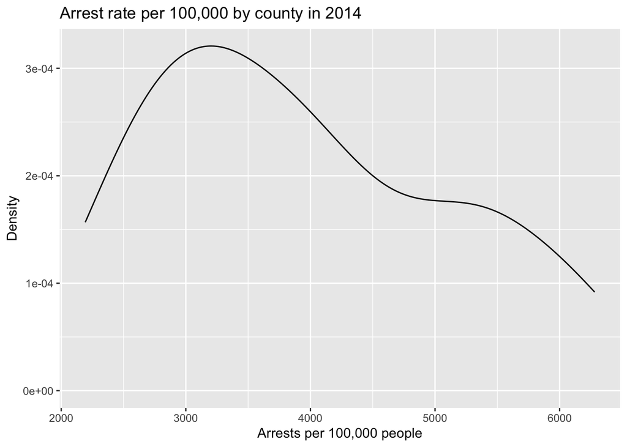

```r
crime |>
  filter(year == 2014) |>
  ggplot(mapping = aes(x = arrests_total_rate_per_100000)) +
  geom_density() +
  labs(x = "Arrests per 100,000 people"
       ,y = "Density"
       ,title = "Arrest rate per 100,000 by county in 2014")
```

3. Compare the distributions of total arrest rate in 2005 and 2014 with overlapping densities. Ans: In 2005, there were a higher number of average arrests, as compared to 2014. For example, as can be seen from this graph, in 2005 (red curve), there were a higher number of counties that arrested more than 6000 people per 100,000, than in 2014 (blue curve)

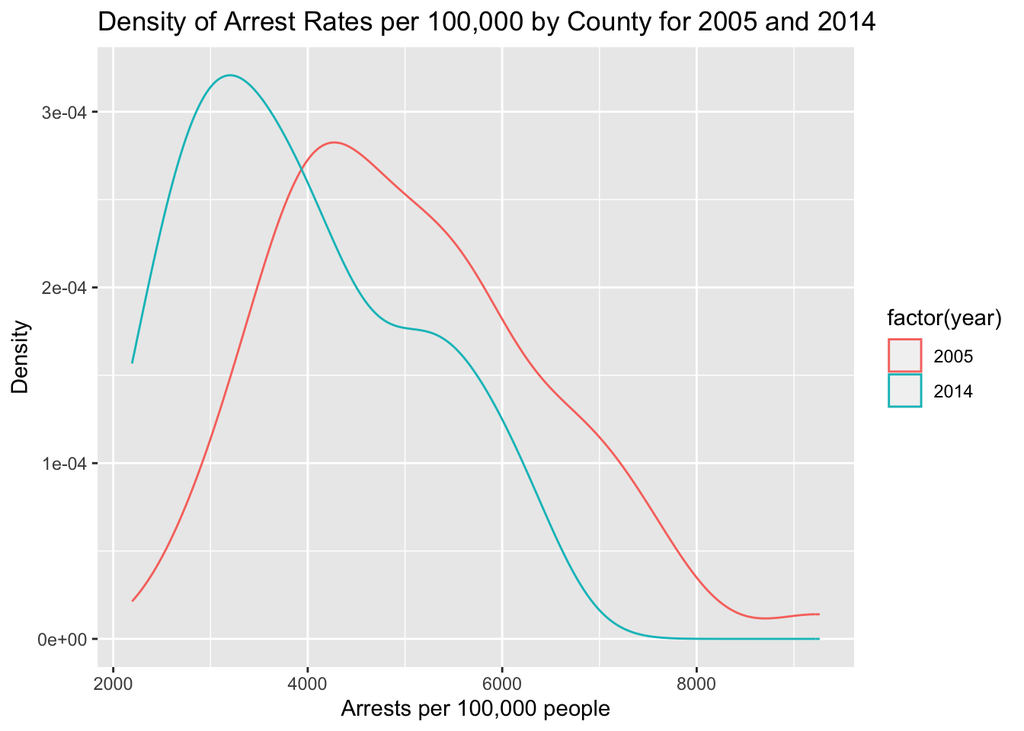

```r
crime |>
  filter(year %in% c(2014,2005)) |>
  ggplot(mapping = aes(x = arrests_total_rate_per_100000, color = factor(year))) +
  geom_density() +
  labs(
    x = "Arrests per 100,000 people",
    y = "Density",
    title = "Density of Arrest Rates per 100,000 by County for 2005 and 2014"
  )
```

4. Re-make this comparison with boxplots. Ans: I changed a few things while plotting a boxplot. I changed the number of arrests from x-axis (in the density plot), to the y axis. The trends however, remain the same. The total number of arrests per 100,000 people (across all counties) have fallen.

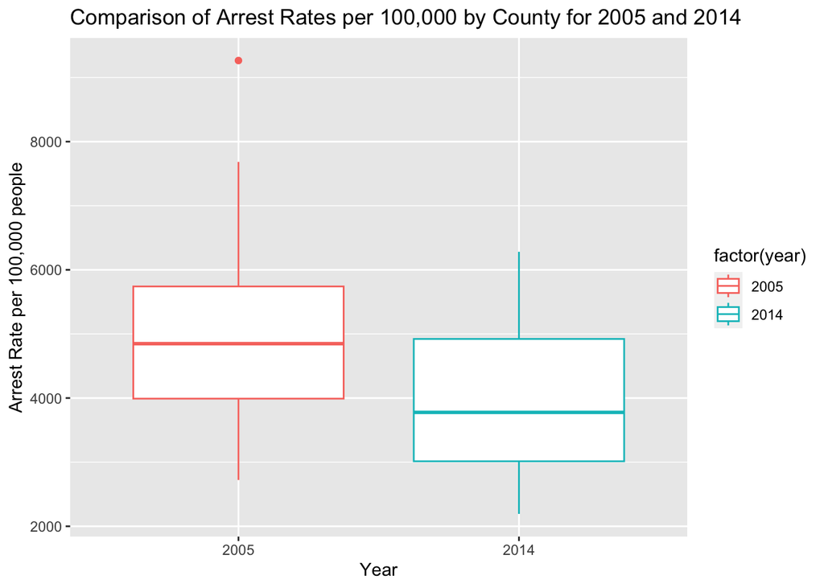

```r
crime |>
  filter(year %in% c(2014, 2005)) |>
  ggplot(mapping = aes(x = factor(year), y = arrests_total_rate_per_100000, color = factor(year))) +
  geom_boxplot() +
  labs(
    x = "Year",
    y = "Arrest Rate per 100,000 people",
    title = "Comparison of Arrest Rates per 100,000 by County for 2005 and 2014")
```

5. Make a scatterplot of the property crime rate and violent crime rate by county in 2014.

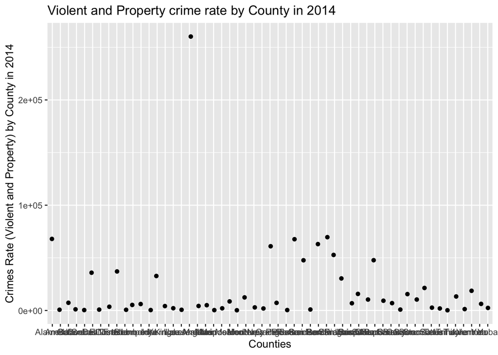

```r
crime |>
  filter(year == 2014) |>
  ggplot() +
  geom_jitter(mapping = aes(x = factor(county), y = violent_crimes + property_crimes), width = 0.2) +
  labs(
    x = "Counties",
    y = "Crimes Rate (Violent and Property) by County in 2014",
    title = "Violent and Property crime rate by County in 2014"
  )
```

6. Make a line plot of the total arrest rate in Alameda county between 2005 and 2014. Ans: The arrests in Alameda county have decreased over the years.

I also added the scales part because the years were in decimal points for some reason.

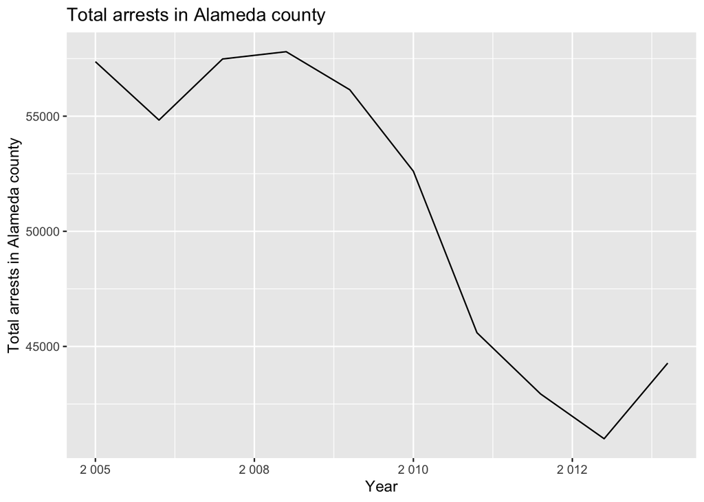

```r
library(scales)
crime |>
  filter(county == "Alameda") |>
  ggplot(mapping = aes(x = year, y = arrests_total)) +
  geom_line() +
  labs(x = "Year",
    y = "Total arrests in Alameda county",
    title = "Total arrests in Alameda county") +
    scale_x_continuous(labels = label_number(accuracy = 1))
```

7. The five largest counties (by `population_served`) are given in the R code. On the same plot, make line plots of the arrest rates for these five counties between 2005 and 2014.

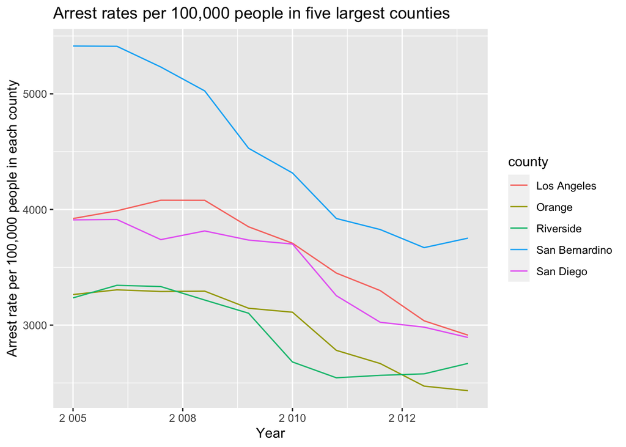

```r
five_largest_counties <- c("Los Angeles", "Orange", "Riverside", "San Bernardino", "San Diego")

#install.packages("scales")
library(scales)

crime |>
  filter(county %in% c("Los Angeles", "Orange", "Riverside", "San Bernardino", "San Diego")) |>
  ggplot(mapping = aes(x = year, y = arrests_total_rate_per_100000, color = county)) +
  geom_line() +
  labs(x = "Year",
    y = "Arrest rate per 100,000 people in each county",
    title = "Arrest rates per 100,000 people in five largest counties") +
    scale_x_continuous(labels = label_number(accuracy = 1))
```

8. (Bonus) Use the `facet` option in `ggplot` to display these line plots as a grid of plots. Ans: I also added the scales part because the years were in decimal points for some reason.

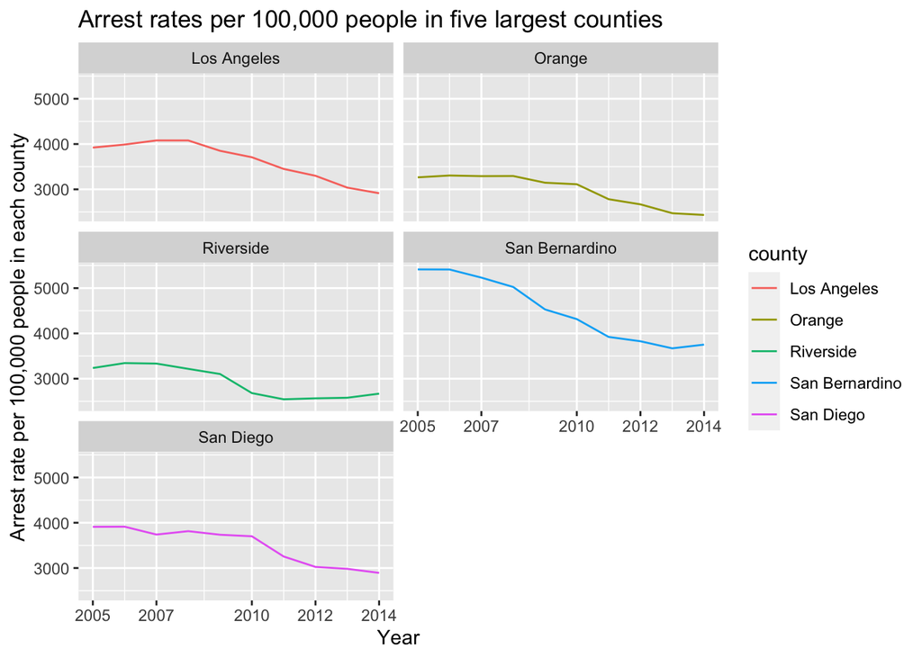

```r
crime |>
  filter(county %in% c("Los Angeles", "Orange", "Riverside", "San Bernardino", "San Diego")) |>
  ggplot(mapping = aes(x = year, y = arrests_total_rate_per_100000, color = county)) +
  geom_line() +
  labs(x = "Year",
    y = "Arrest rate per 100,000 people in each county",
    title = "Arrest rates per 100,000 people in five largest counties") +
  facet_wrap( ~county, nrow = 3) +
  scale_x_continuous(breaks = c(2005,2007,2010,2012, 2014), labels = c("2005", "2007", "2010", "2012", "2014"))
```